# Rank-normalized split-Rhat and relative efficiency estimates

Aki Vehtari, Andrew Gelman, Daniel Simpson, Bob Carpenter, Paul Bürkner

First version 2017-05-23. Last modified 2018-12-03.

# 1 Introduction

The Split-$\widehat{R}$ statistic and the effective sample size $S_{\rm eff}$ (previously called $N_{\rm eff}$ or $n_{\rm eff}$) are routinely used to monitor the convergence of iterative simulations, which are omnipresent in Bayesian statistics in the form of Markov-Chain Monto-Carlo samples. The original $\widehat{R}$ statistic (Gelman and Rubin, 1992; Brooks and Gelman, 1998) and *split*-$\widehat{R}$ (Gelman *et al.*, 2013) are both based on the ratio of between and within-chain marginal variances of the simulations, while the latter is computed from split chains (hence the name).

$\widehat{R}$, *split*-$\widehat{R}$, and $S_{\rm eff}$ are well defined only if the marginal distributions have finite mean and variance. Even if that’s the case, their estimates are less stable for distributions with long tails. To alleviate these problems, we define *split*-$\widehat{R}$ and $S_{\rm eff}$ using rank normalized values, empirical cumulative density functions, and small posterior intervals.

The code for the new *split*-$\widehat{R}$ and $S_{\rm eff}$ versions and for the corresponding diagnostic plots can be found in monitornew.R and monitorplot.R, respectively.

# 2 Review of *split*-$\widehat{R}$ and effective sample size

In this section, we will review the split-$\widehat{R}$ and effective sample size estimates as implemented in Stan 2.18 (Stan Development Team, 2018e). These implementations represent the current de facto standard of convergence diagnostics for iterative simulations.

## 2.1 *Split*-$\widehat{R}$

Below, we present the computation of *Split*-$\widehat{R}$ following Gelman *et al.* (2013), but using the notation style of Stan Development Team (2018a). Our general recommendation is to always run several chains. $N$ is the number of draws per chain, $M$ is the number of chains, and $S=MN$ is the total number of draws from all chains. For each scalar summary of interest $\theta$, we compute $B$ and $W$, the between- and within-chain variances:

$$B = \frac{N}{M-1}\sum_{m=1}^{M}(\overline{\theta}^{(.m)}-\overline{\theta}^{(..)})^2,
\;\mbox{ where }\;\;\overline{\theta}^{(.m)}=\frac{1}{N}\sum_{n=1}^N \theta^{(nm)},\;\;
\;\;\overline{\theta}^{(..)} = \frac{1}{M}\sum_{m=1}^M\overline{\theta}^{(.m)}
\\
W = \frac{1}{M}\sum_{m=1}^{M}s_j^2, \;\mbox{ where }\;\; s_m^2=\frac{1}{N-1}
\sum_{n=1}^N (\theta^{(nm)}-\overline{\theta}^{(.m)})^2.$$

The between-chain variance, $B$, also contains the factor $N$ because it is based on the variance of the within-chain means, $\overline{\theta}^{(.m)}$, each of which is an average of $N$ values $\theta^{(nm)}$.

We can estimate $\mbox{var}(\theta \mid y)$, the marginal posterior variance of the estimand, by a weighted average of $W$ and $B$, namely
$$\widehat{\mbox{var}}^+(\theta \mid y)=\frac{N-1}{N}W + \frac{1}{N}B.$$
This quantity *overestimates* the marginal posterior variance assuming the starting distribution of the simulations is appropriately overdispersed compared to the target distribution, but is *unbiased* under stationarity (that is, if the starting distribution equals the target distribution), or in the limit $N\rightarrow\infty$. To have an overdispersed starting distribution, independent Markov chains should be initialized with diffuse starting values for the parameters.

Meanwhile, for any finite $N$, the within-chain variance $W$ should *underestimate* $\mbox{var}(\theta \mid y)$ because the individual chains haven’t had the time to explore all of the target distribution and, as a result, will have less variability. In the limit as $N\rightarrow\infty$, the expectation of $W$ also approaches $\mbox{var}(\theta \mid y)$.

We monitor convergence of the iterative simulations to the target distribution by estimating the factor by which the scale of the current distribution for $\theta$ might be reduced if the simulations were continued in the limit $N\rightarrow\infty$. This potential scale reduction is estimated as
$$\widehat{R}=
\sqrt{\frac{\widehat{\mbox{var}}^+(\theta \mid y)}{W}},$$
which declines to 1 as $N\rightarrow\infty$. We call this *split*-$\widehat{R}$ because we are applying it to chains that have been split in half so that $M$ is twice the number of actual chains. Without splitting, $\widehat{R}$ would get fooled by non-stationary chains (see Appendix D).

We note that *split*-$\widehat{R}$ is also well defined for sequences that are not Markov-chains. However, for simplicity, we always refer to ‘chains’ instead of more generally to ‘sequences’ as the former is our primary use case for $\widehat{R}$-like measures.

## 2.2 Effective sample size $S_{\rm eff}$

If the $N$ simulation draws within each chain were truly independent, the between-chain variance $B$ would be an unbiased estimate of the posterior variance, $\mbox{var}(\theta \mid y)$, and we would have a total of $S = MN$ independent simulations from the $M$ chains. In general, however, the simulations of $\theta$ within each chain will be autocorrelated, and thus $B$ will be larger than $\mbox{var}(\theta \mid y)$, in expectation.

A nice introductory reference for analyzing MCMC results in general and effective sample size in particular is provided by Geyer (2011, see also 1992). The particular calculations used by Stan (Stan Development Team, 2018e) follow those for split-$\widehat{R}$, which involve both between-chain (mean) and within-chain calculations (autocorrelation). They were introduced in the Stan manual (Stan Development Team, 2018d) and explained in more detail in Gelman *et al.* (2013).

One way to define effective sample size for correlated simulation draws is to consider the statistical efficiency of the average of the simulations $\bar{\theta}^{(..)}$ as an estimate of the posterior mean $\mbox{E}(\theta \mid y)$. This generalizes also to posterior expectations of functionals of parameters $\mbox{E}(g(\theta) \mid y)$ and we return later to how to estimate the effective sample size of quantiles which cannot be presented as expectations. For simplification, in this section we consider the effective sample size for the posterior mean.

The effective sample size of a chain is defined in terms of the autocorrelations within the chain at different lags. The autocorrelation $\rho_t$ at lag $t \geq 0$ for a chain with joint probability function $p(\theta)$ with mean $\mu$ and variance $\sigma^2$ is defined to be
$$\rho_t
=
\frac{1}{\sigma^2} \, \int_{\Theta} (\theta^{(n)} - \mu)
(\theta^{(n+t)} - \mu) \, p(\theta) \, d\theta.$$
This is just the correlation between the two chains offset by $t$ positions. Because we know $\theta^{(n)}$ and $\theta^{(n+t)}$ have the same marginal distribution in an MCMC setting, multiplying the two difference terms and reducing yields
$$\rho_t
=
\frac{1}{\sigma^2} \, \int_{\Theta} \theta^{(n)} \, \theta^{(n+t)} \, p(\theta) \, d\theta.$$

The effective sample size of one chain generated by a process with autocorrelations $\rho_t$ is defined by
$$N_{\rm eff}
\ = \
\frac{N}{\sum_{t = -\infty}^{\infty} \rho_t}
\ = \
\frac{N}{1 + 2 \sum_{t = 1}^{\infty} \rho_t}.$$

Effective sample size $N_{\rm eff}$ can be larger than $N$ in case of antithetic Markov chains, which have negative autocorrelations on odd lags. The Dynamic Hamiltonian Monte-Carlo algorithms used in Stan (Hoffman and Gelman, 2014; Betancourt, 2017) can produce $N_{\rm eff}>N$ for parameters with a close to Gaussian posterior (in the unconstrained space) and low dependency on other parameters.

### 2.2.1 Estimation of the Effective Sample Size

In practice, the probability function in question cannot be tractably integrated and thus neither autocorrelation nor the effective sample size can be calculated. Instead, these quantities must be estimated from the samples themselves. The rest of this section describes an autocorrelation and split-$\widehat{R}$ based effective sample size estimator, based on multiple split chains. For simplicity, each chain will be assumed to be of the same length $N$.

Stan carries out the autocorrelation computations for all lags simultaneously using Eigen’s fast Fourier transform (FFT) package with appropriate padding; see Geyer (2011) for more details on using FFT for autocorrelation calculations. The autocorrelation estimates $\hat{\rho}_{t,m}$ at lag $t$ from multiple chains $m \in (1,\ldots,M)$ are combined with the within-chain variance estimate $W$ and the multi-chain variance estimate $\widehat{\mbox{var}}^{+}$ introduced in the previous section to compute the combined autocorrelation at lag $t$ as
$$\hat{\rho}_t
= 1 - \frac{\displaystyle W - \textstyle \frac{1}{M}\sum_{m=1}^M
\hat{\rho}_{t,j}}{\widehat{\mbox{var}}^{+}}. \label{rhohat}$$
If the chains have not converged, the variance estimator $\widehat{\mbox{var}}^{+}$ will overestimate the true marginal variance which leads to an overestimation of the autocorrelation and an underestimation of the effective sample size.

Because of noise in the correlation estimates $\hat{\rho}_t$ increases as $t$ increases, typically the truncated sum of $\hat{\rho}_t$ is used. Negative autocorrelations can happen only on odd lags and by summing over pairs starting from lag $t=0$, the paired autocorrelation is guaranteed to be positive, monotone and convex modulo estimator noise (Geyer, 1992, 2011). Stan 2.18 uses Geyer’s initial monotone sequence criterion. The effective sample size of combined chains is defined as
$$S_{\rm eff} = \frac{N \, M}{\hat{\tau}},$$
where
$$\hat{\tau} = 1 + 2 \sum_{t=1}^{2k+1} \hat{\rho}_t =
-1 + 2 \sum_{t'=0}^{k} \hat{P}_{t'},$$
and $\hat{P}_{t'}=\hat{\rho}_{2t'}+\hat{\rho}_{2t'+1}$. The initial positive sequence estimator is obtained by choosing the largest $k$ such that $\hat{P}_{t'}>0$ for all $t' = 1,\ldots,k$. The initial monotone sequence estimator is obtained by further reducing $\hat{P}_{t'}$ to the minimum of the preceding values so that the estimated sequence becomes monotone.

The effective sample size $S_{\rm eff}$ described here is different from similar formulas in the literature in that we use multiple chains and between-chain variance in the computation, which typically gives us more conservative claims (lower values of $S_{\rm eff}$) compared to single chain estimates, especially when mixing of the chains is poor. If the chains are not mixing at all (e.g., the posterior is multimodal and the chains are stuck in different modes), then our $S_{\rm eff}$ is close to the number of chains.

Before version 2.18, Stan used a slightly incorrect initial sequence which implied that $S_{\rm eff}$ was capped at $S$ and thus the effective sample size was underestimated for some models. As antithetic behavior (i.e., $S_{\rm eff} > S$) is not that common or the effect is small, and capping at $S$ can be considered to be pessimistic, this had negligible effect on any inference. However, it may have led to an underestimation of Stan’s efficiency when compared to other packages performing MCMC sampling.

# 3 Rank normalized *split*-$\widehat{R}$ and relative efficiency estimates

As *split*-$\widehat{R}$, and $S_{\rm eff}$ are well defined only if the marginal posteriors have finite mean and variance, we next introduce *split*-$\widehat{R}$ and $S_{\rm eff}$ using rank normalized values, empirical cumulative density functions, and small posterior intervals which are well defined for all distributions and more robust for long tailed distributions.

## 3.1 Rank normalized *split*-$\widehat{R}$

Rank normalized *split*-$\widehat{R}$ is computed using the equations in Section *Split*-$\widehat{R}$ by replacing the original parameter values $\theta^{(nm)}$ with their corresponding rank normalized values $z^{(nm)}$.

Rank normalization: 1. Rank: Replace each value $\theta^{(nm)}$ by its rank $r^{(nm)}$. Average rank for ties are used to conserve the number of unique values of discrete quantities. Ranks are computed jointly for all draws from all chains. 2. Normalize: Normalize ranks by inverse normal transformation $z^{(nm)} = \phi^{-1}((r^{(nm)}-1/2)/S)$.

Appendix B illustrates the rank normalization of multiple chains.

For continuous variables and $S \rightarrow \infty$, the rank normalized values are normally distributed and rank normalization performs non-parametric transformation to normal distribution. Using normalized ranks instead of ranks directly, has the benefit that the behavior of $\widehat{R}$ and $S_{\rm eff}$ do not change for normally distributed $\theta$.

## 3.2 Rank normalized *folded-split*-$\widehat{R}$

Both original and rank-normalized *split*-$\widehat{R}$ can be fooled if chains have different scales but the same location (see Appendix D). To alleviate this problem, we propose to compute rank normalized *folded-split*-$\widehat{R}$ using *folded* split chains by rank normalizing absolute deviations from median
$${\rm abs}(\theta^{(nm)}-{\rm median}(\theta)).$$

To obtain a single conservative $\widehat{R}$ estimate, we propose to report the maximum of rank normalized *split*-$\widehat{R}$ and rank normalized *folded-split*-$\widehat{R}$ for each parameter.

## 3.3 Relative efficiency using rank normalized values

In addition to using rank-normalized values for convergence diagnostics via $\widehat{R}$, we can also compute the corresponding effective sample size. This estimate will be well defined even if the original distribution does not have finite mean and variance. It is not directly applicable to estimate the Monte Carlo error of the mean of the original values, but it will provide a bijective transformation-invariant estimate of the mixing efficiency of chains. For simplicity we propose to report relative efficiency values
$$R_{\rm eff}=\textit{rank-normalized-split-}S_{\rm eff} / S,$$
where $\textit{split-}S_{\rm eff}$ is computed using equations in Section Effective sample size by replacing parameter values $\theta^{(nm)}$ with rank normalized values $z^{(nm)}$. For parameters with a close to normal distribution, the difference to using the original values is small. However, for parameters with a distribution far from normal, rank normalization can be seen as a near optimal non-parametric transformation.

The relative efficiency estimate using rank normalized values is a useful measure for relative efficiency of estimating the bulk (mean and quantiles near the median) of the distribution, and as shorthand term we use term *bulk relative efficiency* (*bulk*-$R_{\rm eff}$). Bulk relative efficiency estimate is also useful for diagnosing problems due to trends or different means of the chains (see Appendix D).

We propose to compute the relative efficiency also using *folded* split chains by rank normalizing absolute deviations from median (see above), which is a useful measure for the relative efficiency of estimating the distributions’ tail. As a shorthand, we use the term *tail relative efficiency* (*tail*-$R_{\rm eff}$). Tail relative efficiency estimate is also useful for diagnosing problems due to different scales of the chains (see Appendix D).

## 3.4 Relative efficiency of the cumulative distribution function

The bulk and tail relative efficiency measures introduced above are useful as overall efficiency measures. Next, we introduce relative efficiency estimates of the cumulative distribution function (CDF), and later we use that to introduce relative efficiency diagnostics of quantiles and local small probability intervals.

Quantiles and posterior intervals derived on their basis are often reported quantities which are easy to estimate from posterior draws. Estimating the relative efficiency of such quantiles thus has a high practical relevance in particular as we observe the relative efficiency for tail quantiles to often be lower than for the mean or median. The $\alpha$-quantile is defined as the parameter value $\theta_\alpha$ for which $p(\theta \leq \theta_\alpha) = \alpha$. An estimate $\hat{\theta}_\alpha$ of $\theta_\alpha$ can thus be obtained by finding the $\alpha$-quantile of the empirical CDF (ECDF) of the posterior draws $\theta^{(s)}$. However, quantiles cannot be written as an expectation, and thus the above equations for $\widehat{R}$ and $S_{\rm eff}$ are not directly applicable. Thus, we first focus on the relative efficiency of the cumulative probability $p(\theta \leq \theta_\alpha)$ for different values of $\theta_\alpha$.

For any $\theta_\alpha$, the ECDF gives an estimate of the cumulative probability
$$p(\theta \leq \theta_\alpha) \approx \bar{I}_\alpha = \frac{1}{S}\sum_{s=1}^S
I(\theta^{(s)} \leq\theta_\alpha),$$
where $I()$ is the indicator function. The indicator function transforms simulation draws to 0’s and 1’s, and thus the subsequent computations are bijectively invariant. Efficiency estimates of the ECDF at any $\theta_\alpha$ can now be obtained by applying rank-normalizing and subsequent computations directly on the indictor function’s results. See Appendix C for an illustration of variance of ECDF.

## 3.5 Relative efficiency of quantiles

Assuming that we know the CDF to be a certain continuous function $F$ which is smooth near an $\alpha$-quantile of interest, we could use the delta method to compute a variance estimate for $F^{-1}(\bar{I}_\alpha)$. Although we don’t usually know $F$, the delta method approach reveals that the variance of $\bar{I}_\alpha$ for some $\theta_\alpha$ is scaled by the (usually unknown) density $f(\theta_\alpha)$, but the relative efficiency depends only on the relative efficiency of $\bar{I}_\alpha$. Thus, we can use the relative efficiency of the ECDF computed via the indicator function $I(\theta^{(s)} \leq \theta_\alpha)$ also for the corresponding quantile estimates.

## 3.6 Relative efficiency of median and MAD

Since the marginal posterior distributions might not have finite mean and variance, by default RStan (Stan Development Team, 2018c) and RStanARM (Stan Development Team, 2018b) report median and median absolute deviation (MAD) instead of mean and standard error (SE). Median and MAD are well defined even when the marginal distribution does not have finite mean and variance. Since the median is just 50%-quantile, we can estimate its relative efficiency as for any other quantile.

We can also compute the relative efficiency for the median absolute deviation (MAD), by computing the relative efficiency for the median of absolute deviations from the median of all draws. The absolute deviations from the median of all draws are same as previously defined for folded samples
$${\rm abs}(\theta^{(nm)}-{\rm median}(\theta)).$$
We see that the relative efficiency of MAD is obtained by using the same approach as for the median (and other quantiles) but with the folded values also used in *rank-normalized-folded-split*-$S_{\rm eff}$.

## 3.7 Monte Carlo error estimates for quantiles

Previously, Stan has reported Monte Carlo standard error estimates for the mean of a quantity. This is valid only if the corresponding marginal distribution has finite mean and variance; and even if valid, it may be easier and more robust to focus on the median and other quantiles, instead.

Median, MAD and quantiles are well defined even when the distribution does not have finite mean and variance, and they are asymptotically normal for continuous distributions which are non-zero in the relevant neighborhood. As the delta method for computing the variance would require explicit knowledge of the normalized posterior density, we propose the following alternative approach:

1. Compute quantiles of the ${\rm Beta}(R_{\rm eff} \bar{I}_\alpha+1, R_{\rm eff}(1-\bar{I}_\alpha)+1)$ distribution. Including $R_{\rm eff}$ takes into account the relative efficiency of the posterior draws.
2. Find indices in $\{1,\ldots,S\}$ closest to the ranks of these quantiles. For example, for quantile $Q$, find $s = {\rm round(Q S)}$.
3. Use the corresponding $\theta^{(s)}$ from the list of sorted posterior draws as quantiles from the error distribution. These quantiles can be used to approximate the Monte Carlo standard error.

## 3.8 Relative efficiency of small interval probability estimates

We can get more local relative efficiency estimates by considering small probability intervals. We propose to compute the relative efficiencies for
$$\bar{I}_{\alpha,\delta} = p(\hat{Q}_\alpha < \theta \leq \hat{Q}_{\alpha+\delta}),$$
where $\hat{Q}_\alpha$ is an empirical $\alpha$-quantile, $\delta=1/k$ is the length of the interval with some positive integer $k$, and $\alpha \in (0,\delta,\ldots,1-\delta)$ changes in steps of $\delta$. Each interval has $S/k$ draws, and the efficiency measures autocorrelation of an indicator function which is $1$ when the values are inside the specific interval and $0$ otherwise. This gives us a local efficiency measure which does not depend on the shape of the distribution.

## 3.9 Rank plots

In addition to using rank-normalized values to compute *split*-$\widehat{R}$, we propose to use rank plots for each chain instead of trace plots. Rank plots are nothing else than histograms of the ranked posterior samples (ranked over all chains) plotted separately for each chain. If rank plots of all chains look similar, this indicates good mixing of the chains. As compared to trace plots, rank plots don’t tend to squeeze to a mess in case of long chains.

## 3.10 Proposed changes in Stan

The proposal is to switch in Stan:

- from split-$\widehat{R}$ to the maximum of rank-normalized-split-$\widehat{R}$ and rank-normalized-folded-split-$\widehat{R}$
- from the classic effective sample size estimate, which currently doesn’t use chain splitting, to rank-normalized-split-$R_{\rm eff}$ and rank-normalized-folded-split-$R_{\rm eff}$
- instead of mean and std, report only quantiles and compute Monte Carlo error for each quantile computed
- if computing MAD_SD, report the corresponding MCSE

Justifications for the changes are:

- Rank normalization makes $\widehat{R}$ and (relative) effective sample size measures well defined for all distributions, invariant under bijective transformations, and more stable than their classical counterparts.
- Adding folded versions of $\widehat{R}$ and (relative) effective sample size helps in detecting scale differences across chains.
- Monte Carlo SE’s of the quantiles and MAD_SD are well defined, they can be quite different for different quantiles and MAD_SD, and it’s difficult to compute MCSE in head from the sample size alone.

In summary outputs, we propose to use `Rhat` to denote also the new version. However, to make it more explicit that the rank-normalized efficiency is different than standard efficiency, we could use the term `Reff` to denote relative efficiency instead of using `Neff` for the effective sample size (i.e. absolute efficiency). The relative efficiency is also easier to check for low values as we don’t need to compare it to the total number of draws. There are cases where the effective sample size `Seff` might be useful, so function to compute that is useful to be available.

## 3.11 Proposed additions to bayesplot

We propose to add to the **bayesplot** package:

- Rank plots
- Plots for relative efficiency of quantiles
- Plots for relative efficiency of small probability intervals

## 3.12 Warning thresholds

Based on the experiments presented in Appendices D-F, more strict convergence diagnostics and relative efficiency warning limits could be used. We propose the following warning thresholds although additional experiments would be useful:

Plots shown in the upcoming sections have dashed lines based on these thresholds (in continuous plots, a dashed line at 1.005 is plotted instead of 1.01, as values larger than that are usually rounded in our summaries to 1.01).

# 4 Examples

In this section, we will go through some examples to demonstrate the usefulness of our proposed methods as well as the associated workflow in determining convergence. Appendices D-G contain more detailed analysis of different algorithm variants and further examples.

First, we load all the necessary R packages and additional functions.

```r
library(tidyverse)
library(gridExtra)
library(rstan)
options(mc.cores = parallel::detectCores())
rstan_options(auto_write = TRUE)
library(bayesplot)
theme_set(bayesplot::theme_default(base_family = "sans"))
source('monitornew.R')
source('monitorplot.R')
```

## 4.1 Cauchy: A distribution with infinite mean and variance

The classic *split*-$\widehat{R}$ is based on calculating within and between chain variances. If the marginal distribution of a chain is such that the variance is not defined (i.e., infinite), the classic *split*-$\widehat{R}$ is not well justified. In this section, we will use the Cauchy distribution as an example of such a distribution. Appendix E contains more detailed analysis of different algorithm variants and further Cauchy examples.

The following Cauchy models are from Michael Betancourt’s case study [Fitting The Cauchy Distribution](https://betanalpha.github.io/assets/case_studies/fitting_the_cauchy.html)

### 4.1.1 Nominal parameterization of Cauchy

The nominal Cauchy model with direct parameterization is as follows:

```r
writeLines(readLines("cauchy_nom.stan"))
```

```
parameters {
  vector[50] x;
}

model {
  x ~ cauchy(0, 1);
}

generated quantities {
  real I = fabs(x[1]) < 1 ? 1 : 0;
}
```

#### 4.1.1.1 Default Stan options

Run the nominal model:

```r
fit_nom <- stan(file = 'cauchy_nom.stan', seed = 7878, refresh = 0)
```

```
Warning: There were 1233 transitions after warmup that exceeded the maximum treedepth. Increase max_treedepth above 10. See
http://mc-stan.org/misc/warnings.html#maximum-treedepth-exceeded
```

```
Warning: Examine the pairs() plot to diagnose sampling problems
```

```r
mon <- monitor(fit_nom)
print(mon)
```

```
Inference for the input samples (4 chains: each with iter = 2000; warmup = 1000):

          Q5    Q50    Q95 SE_Q5 SE_Q50 SE_Q95 Rhat Bulk_Reff Tail_Reff
x[1]   -5.74  -0.01   6.31  1.05   0.03   1.49 1.03      0.30      0.06
x[2]   -5.83  -0.01   6.07  0.90   0.03   1.25 1.01      0.66      0.11
x[3]   -5.23   0.01   5.73  0.69   0.03   0.76 1.01      0.67      0.13
x[4]   -6.25  -0.02   6.90  1.03   0.03   1.19 1.01      0.91      0.10
x[5]   -9.66  -0.05   5.11  5.56   0.03   0.79 1.01      0.16      0.08
x[6]   -5.26   0.00   5.41  0.56   0.02   0.66 1.01      0.77      0.14
x[7]   -6.35   0.06  10.77  0.98   0.03   4.44 1.02      0.15      0.07
x[8]   -6.45  -0.01   5.37  0.65   0.02   0.72 1.00      0.66      0.11
x[9]   -6.53   0.00   6.30  0.67   0.03   0.59 1.01      0.78      0.12
x[10]  -6.12  -0.01   5.92  0.62   0.02   0.83 1.01      0.61      0.11
x[11]  -6.73   0.00   6.15  1.04   0.02   1.09 1.01      0.52      0.10
x[12]  -5.68  -0.03   4.88  0.63   0.03   0.70 1.00      0.66      0.13
x[13]  -4.53  -0.06   4.27  0.38   0.02   0.53 1.00      0.79      0.16
x[14]  -4.88   0.00   5.03  0.90   0.02   0.99 1.00      0.37      0.14
x[15] -14.49  -0.01  11.51  7.43   0.05   3.52 1.03      0.12      0.05
x[16]  -7.03   0.01   6.96  1.54   0.03   0.99 1.01      0.58      0.08
x[17]  -6.59   0.01   7.69  1.19   0.02   2.03 1.01      0.57      0.10
x[18]  -4.51   0.05   6.92  0.49   0.03   1.53 1.01      0.66      0.08
x[19]  -7.66  -0.05   6.08  2.84   0.02   1.03 1.01      0.29      0.11
x[20]  -5.78   0.03  11.33  0.81   0.03   9.28 1.03      0.09      0.04
x[21]  -4.89   0.02   5.38  0.72   0.02   0.76 1.01      0.82      0.12
x[22]  -5.59   0.04   5.37  0.94   0.02   1.12 1.01      0.53      0.10
x[23] -14.45   0.01   7.00 29.24   0.03   2.10 1.01      0.10      0.06
x[24]  -5.93  -0.04   5.47  1.56   0.02   0.80 1.02      0.36      0.07
x[25]  -7.07  -0.02   5.94  1.87   0.03   0.72 1.01      0.39      0.09
x[26]  -8.96  -0.06   5.85  2.17   0.04   0.59 1.01      0.44      0.09
x[27]  -8.81  -0.01   8.34  2.63   0.02   2.05 1.00      0.45      0.07
x[28]  -5.26   0.02   5.93  1.11   0.03   0.99 1.02      0.94      0.11
x[29]  -5.88   0.00   5.90  0.78   0.03   0.81 1.01      0.91      0.11
x[30]  -5.57  -0.02   5.14  0.98   0.02   0.58 1.00      1.09      0.12
x[31]  -7.36   0.01   7.25  0.75   0.02   0.84 1.00      0.85      0.11
x[32]  -8.85  -0.04   6.50  4.24   0.02   0.69 1.01      0.14      0.07
x[33]  -4.79   0.03   4.96  0.70   0.02   0.45 1.01      0.66      0.14
x[34]  -5.91  -0.03   5.37  0.81   0.03   0.89 1.01      0.60      0.13
x[35]  -6.10   0.02   6.79  0.98   0.03   1.05 1.01      0.66      0.10
x[36]  -4.86   0.10  15.60  0.70   0.05  70.12 1.04      0.04      0.03
x[37]  -8.93   0.00   7.86  2.14   0.03   1.86 1.01      0.29      0.09
x[38]  -5.54  -0.02   4.83  1.16   0.02   0.66 1.00      0.84      0.12
x[39]  -5.89  -0.03   5.84  1.05   0.02   0.94 1.02      1.12      0.11
x[40]  -8.71   0.01   6.71  4.36   0.02   1.16 1.00      0.22      0.06
x[41]  -6.88  -0.03   7.55  1.44   0.03   1.13 1.00      0.43      0.09
x[42]  -6.15   0.01   6.48  1.09   0.02   1.45 1.01      0.38      0.09
x[43]  -6.38   0.00   7.39  1.32   0.03   1.46 1.01      0.69      0.08
x[44]  -7.84   0.00   7.99  1.06   0.03   1.69 1.01      0.75      0.12
x[45]  -4.77  -0.02   4.66  0.40   0.03   0.35 1.01      0.73      0.14
x[46]  -4.84   0.00   5.99  0.69   0.03   1.13 1.00      0.24      0.11
x[47]  -8.51   0.03  24.26  4.93   0.05  22.21 1.07      0.06      0.02
x[48]  -6.73   0.00   5.33  1.32   0.03   0.71 1.01      0.48      0.10
x[49]  -6.27   0.04   6.92  0.92   0.03   1.65 1.00      0.37      0.09
x[50]  -5.21   0.00   4.65  0.66   0.02   0.64 1.00      0.78      0.13
I       0.00   0.50   1.00  0.00   0.50     NA  NaN      0.10       NaN
lp__  -92.71 -69.21 -49.03  1.74   1.34   0.98 1.05      0.03      0.12

For each parameter, Bulk_Reff and Tail_Reff are crude measures of relative
effective sample size for bulk and tail quantities respectively (good mixing
Reff > 0.1), and Rhat is the potential scale reduction factor on rank normalized
split chains (at convergence, Rhat = 1).
```

```r
which_min_eff <- which.min(mon[1:50, 'Bulk_Reff'])
```

Several Rhat > 1.01 and some Reff < 0.1 indicate that the results should not be trusted. The extended case study rhat_reff_extra has more results with longer chains as well.

We examine the relative efficiency in different parts of the posterior by computing the relative efficiency of small interval probability estimates (see Section Relative efficiency of small interval probability estimates). Each interval contains $1/k$ of the draws (e.g., $5\%$ each, if $k=20$). The small interval efficiency measures mixing of an function which indicates when the values are inside or outside the specific small interval. As detailed above, this gives us a local efficiency measure which does not depend on the shape of the distribution.

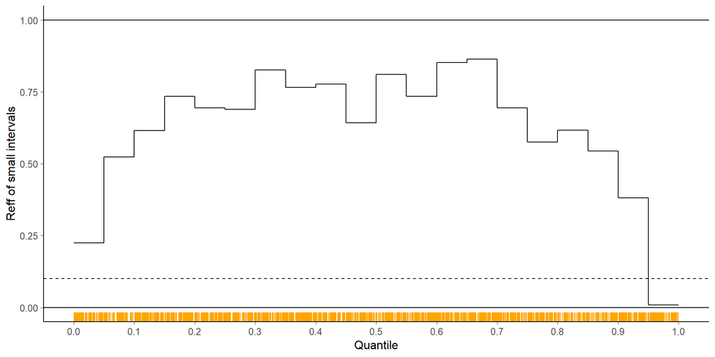

```r
plot_local_reff(fit = fit_nom, par = which_min_eff, nalpha = 20)
```

We see that the efficiency of our posterior draws is worryingly low in the tails (which is caused by slow mixing in long tails of Cauchy). Orange ticks show iterations that exceeded the maximum treedepth.

An alternative way to examine the relative efficiency in different parts of the posterior is to compute relative efficiencies for quantiles (see Section Relative efficiency of quantiles). Each interval has a specified proportion of draws, and the efficiency measures mixing of a function which indicates when the values are smaller than or equal to the corresponding quantile.

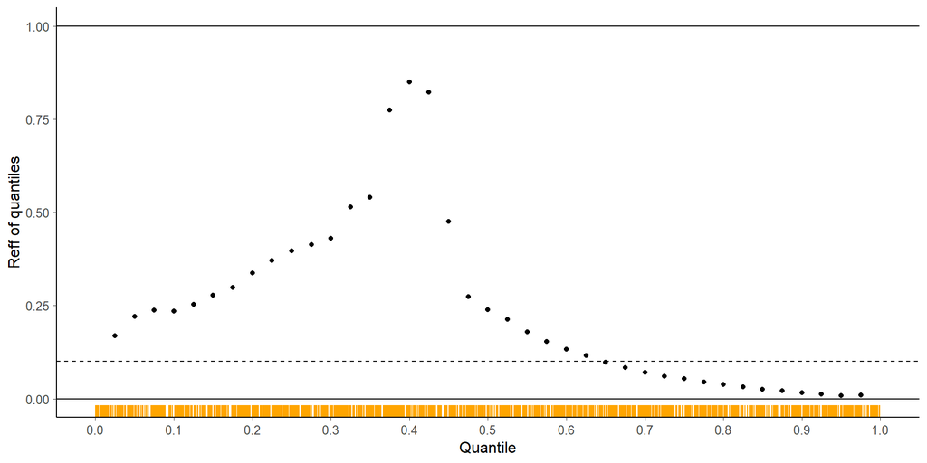

```r
plot_quantile_reff(fit = fit_nom, par = which_min_eff, nalpha = 40)
```

Similar as above, we see that the efficiency of our posterior draws is worryingly low in the tails. Again, orange ticks show iterations that exceeded the maximum treedepth.

We may also investigate how the estimated relative efficiency changes when we use more and more draws. If the relative efficiency is highly unstable or decreases with more draws, this indicates that simply running longer chains will likely not solve the convergence issues. In the plots below, we see how unstable both bulk and tail relative efficiency are for this example.

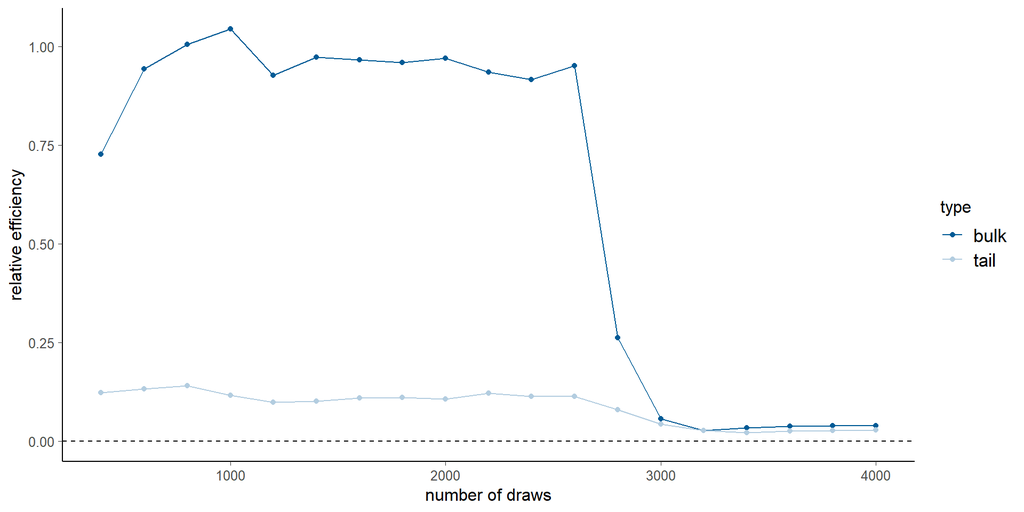

```r
plot_change_reff(fit = fit_nom, par = which_min_eff)
```

We can further analyze potential problems using rank plots in which we clearly see differences between chains.

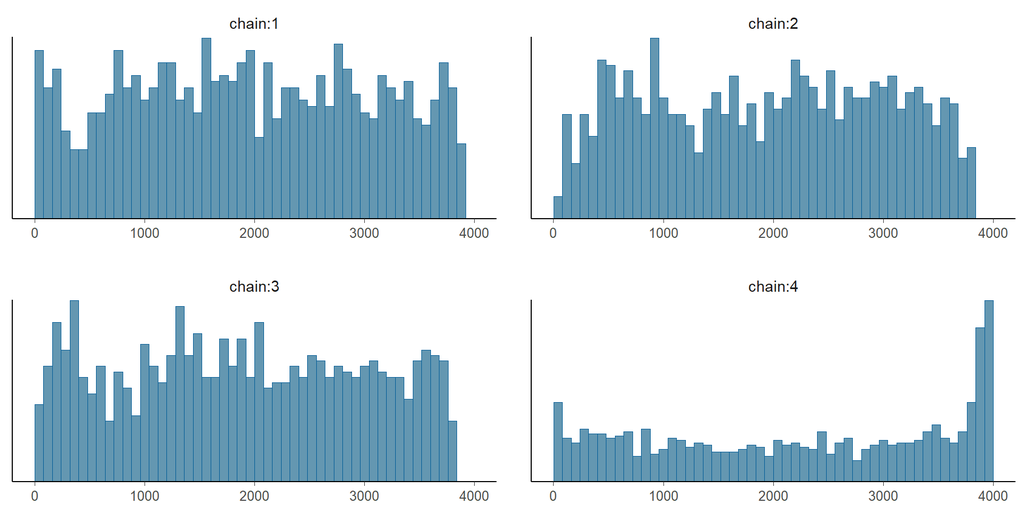

```r
samp <- as.array(fit_nom)
xmin <- paste0("x[", which_min_eff, "]")
mcmc_hist_r_scale(samp[, , xmin])
```

### 4.1.2 Alternative parameterization of Cauchy

Next we examine an alternative parameterization that considers the Cauchy distribution as a scale mixture of Gaussian distributions. The model has two parameters and the Cauchy distributed $x$’s can be computed from those. In addition to improved sampling performance, the example illustrates that focusing on diagnostics matters.

```r
writeLines(readLines("cauchy_alt_1.stan"))
```

```
parameters {
  vector[50] x_a;
  vector<lower=0>[50] x_b;
}

transformed parameters {
  vector[50] x = x_a ./ sqrt(x_b);
}

model {
  x_a ~ normal(0, 1);
  x_b ~ gamma(0.5, 0.5);
}

generated quantities {
  real I = fabs(x[1]) < 1 ? 1 : 0;
}
```

Run the alternative model:

```r
fit_alt1 <- stan(file = 'cauchy_alt_1.stan', seed = 7878, refresh = 0)
```

There are no warnings, and the sampling is much faster.

```r
mon <- monitor(fit_alt1)
print(mon)
```

```
Inference for the input samples (4 chains: each with iter = 2000; warmup = 1000):

            Q5    Q50    Q95 SE_Q5 SE_Q50 SE_Q95 Rhat Bulk_Reff Tail_Reff
x_a[1]   -1.65  -0.02   1.66  0.03   0.03   0.03 1.00      1.09      0.52
x_a[2]   -1.67   0.00   1.63  0.03   0.02   0.04 1.00      1.00      0.61
x_a[3]   -1.66  -0.03   1.62  0.03   0.02   0.05 1.00      1.05      0.61
x_a[4]   -1.63  -0.01   1.69  0.03   0.02   0.05 1.00      0.91      0.55
x_a[5]   -1.64  -0.01   1.58  0.04   0.02   0.02 1.00      0.86      0.62
x_a[6]   -1.62  -0.01   1.56  0.05   0.02   0.04 1.00      0.99      0.61
x_a[7]   -1.61   0.00   1.65  0.05   0.02   0.04 1.00      0.98      0.57
x_a[8]   -1.67  -0.03   1.60  0.03   0.02   0.04 1.00      0.93      0.62
x_a[9]   -1.63  -0.04   1.55  0.04   0.02   0.05 1.00      0.96      0.59
x_a[10]  -1.66  -0.03   1.74  0.04   0.02   0.04 1.00      0.86      0.56
x_a[11]  -1.56  -0.02   1.55  0.03   0.02   0.04 1.00      0.88      0.59
x_a[12]  -1.64   0.00   1.69  0.03   0.02   0.04 1.00      0.87      0.59
x_a[13]  -1.59   0.01   1.63  0.04   0.02   0.03 1.00      0.87      0.57
x_a[14]  -1.72  -0.03   1.63  0.03   0.02   0.04 1.00      0.97      0.54
x_a[15]  -1.65   0.02   1.70  0.05   0.02   0.04 1.00      0.96      0.58
x_a[16]  -1.67  -0.01   1.62  0.04   0.02   0.04 1.00      0.90      0.61
x_a[17]  -1.63  -0.01   1.66  0.04   0.02   0.03 1.00      1.09      0.58
x_a[18]  -1.65  -0.01   1.69  0.03   0.02   0.03 1.00      1.16      0.56
x_a[19]  -1.61  -0.02   1.59  0.03   0.02   0.03 1.00      1.01      0.58
x_a[20]  -1.64  -0.01   1.62  0.04   0.02   0.04 1.00      1.08      0.60
x_a[21]  -1.67   0.04   1.68  0.05   0.02   0.03 1.00      0.91      0.57
x_a[22]  -1.63  -0.01   1.64  0.04   0.02   0.05 1.00      0.99      0.51
x_a[23]  -1.62   0.03   1.70  0.04   0.02   0.05 1.00      1.07      0.56
x_a[24]  -1.66   0.00   1.67  0.04   0.02   0.03 1.00      0.93      0.53
x_a[25]  -1.64   0.02   1.66  0.05   0.02   0.04 1.00      1.10      0.55
x_a[26]  -1.65  -0.02   1.61  0.05   0.02   0.04 1.00      0.96      0.59
x_a[27]  -1.66   0.00   1.68  0.05   0.02   0.03 1.00      0.83      0.53
x_a[28]  -1.69   0.02   1.68  0.04   0.02   0.04 1.00      1.01      0.51
x_a[29]  -1.57   0.00   1.64  0.04   0.02   0.03 1.00      1.02      0.54
x_a[30]  -1.61   0.00   1.64  0.04   0.02   0.04 1.00      0.99      0.55
x_a[31]  -1.65   0.01   1.61  0.04   0.02   0.03 1.00      1.02      0.60
x_a[32]  -1.59  -0.01   1.59  0.03   0.02   0.04 1.00      1.05      0.65
x_a[33]  -1.69  -0.01   1.77  0.04   0.02   0.04 1.00      0.96      0.59
x_a[34]  -1.68   0.01   1.69  0.03   0.02   0.04 1.00      1.00      0.54
x_a[35]  -1.61   0.03   1.67  0.04   0.02   0.05 1.00      0.98      0.58
x_a[36]  -1.67   0.00   1.60  0.04   0.01   0.04 1.00      1.03      0.53
x_a[37]  -1.69  -0.03   1.59  0.04   0.02   0.04 1.00      0.99      0.59
```

[output cut: 105 more lines]

```
x[43]    -5.98  -0.03   6.69  0.41   0.02   0.61 1.00      0.96      0.56
x[44]    -7.04  -0.04   6.17  0.60   0.03   0.63 1.00      0.83      0.56
x[45]    -5.75   0.02   6.23  0.39   0.03   0.58 1.00      0.94      0.55
x[46]    -5.59   0.06   6.33  0.37   0.03   0.93 1.00      0.97      0.47
x[47]    -5.49   0.03   5.43  0.30   0.02   0.45 1.00      0.97      0.69
x[48]    -5.96   0.00   4.85  0.42   0.03   0.38 1.00      0.92      0.58
x[49]    -6.55   0.00   5.25  0.69   0.03   0.43 1.00      0.89      0.52
x[50]    -6.74  -0.01   6.90  0.64   0.03   0.62 1.00      0.86      0.57
I         0.00   0.00   1.00  0.00   0.50     NA 1.00      0.66      0.66
lp__    -95.19 -80.99 -68.66  0.55   0.25   0.26 1.00      0.33      0.59

For each parameter, Bulk_Reff and Tail_Reff are crude measures of relative
effective sample size for bulk and tail quantities respectively (good mixing
Reff > 0.1), and Rhat is the potential scale reduction factor on rank normalized
split chains (at convergence, Rhat = 1).
```

```r
which_min_eff <- which.min(mon[101:150, 'Bulk_Reff'])
```

All Rhat < 1.01 and Reff > 0.1 indicate the sampling worked much better with the alternative parameterization. The extended case study rhat_reff_extra has more results using alternative parameterizations.

We can further analyze potential problems using local relative efficiency and rank plots. We take a detailed look at x[10], which has the smallest bulk relative efficiency of 0.86.

We examine the relative efficiency in different parts of the posterior by computing the relative efficiency of small interval probability estimates.

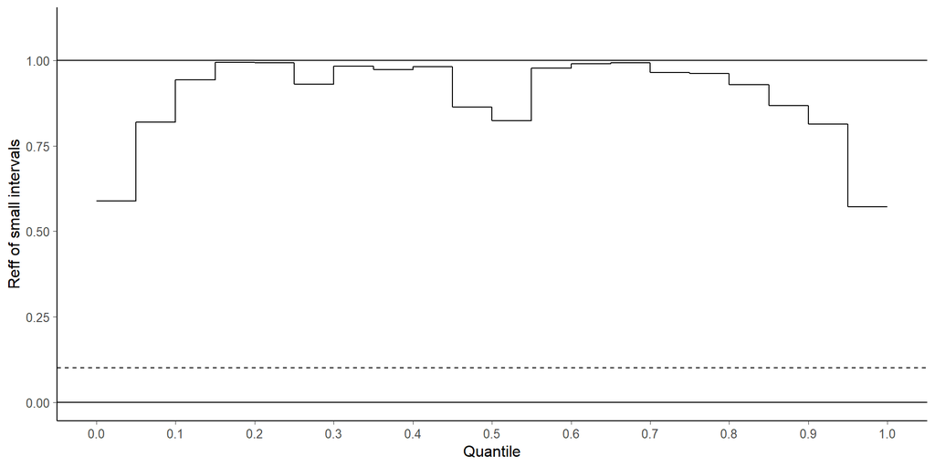

```r
plot_local_reff(fit = fit_alt1, par = which_min_eff + 100, nalpha = 20)
```

The relative efficiency is good in all parts of the posterior. Further, we examine the relative efficiency of different quantile estimates.

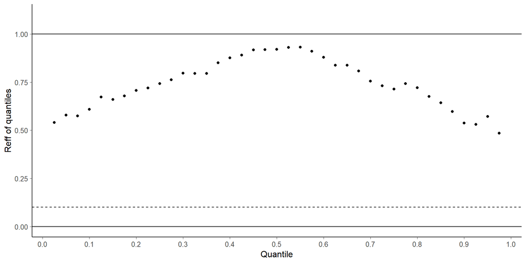

```r
plot_quantile_reff(fit = fit_alt1, par = which_min_eff + 100, nalpha = 40)
```

Rank plots also look rather similar across chains.

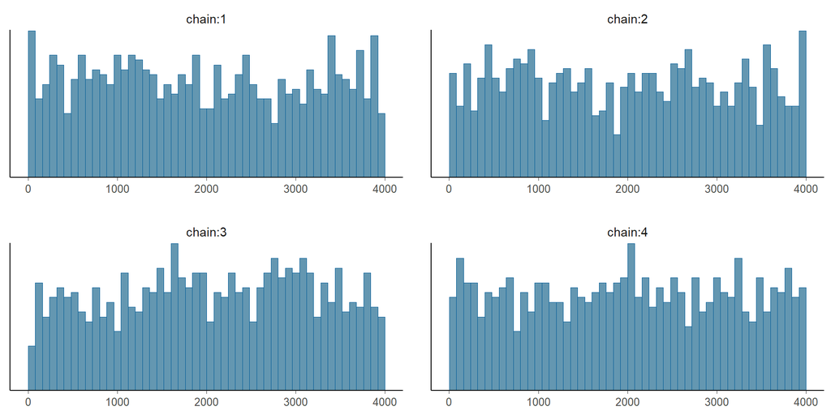

```r
samp <- as.array(fit_alt1)
xmin <- paste0("x[", which_min_eff, "]")
mcmc_hist_r_scale(samp[, , xmin])
```

In summary, the alterative parameterization produces results that look much better than for the nominal parameterization. There are still some differences in the tails, which we also identified via the tail relative efficiency estimates.

### 4.1.3 Half-Cauchy with nominal parameterization

Half-Cauchy priors are common and, for example, in Stan usually set using the nominal parameterization. However, when the constraint `<lower=0>` is used, Stan does the sampling automatically in the unconstrained `log(x)` space, which changes the geometry crucially.

```r
writeLines(readLines("half_cauchy_nom.stan"))
```

```
parameters {
  vector<lower=0>[50] x;
}

model {
  x ~ cauchy(0, 1);
}

generated quantities {
  real I = fabs(x[1]) < 1 ? 1 : 0;
}
```

Run the half-Cauchy with nominal parameterization (and positive constraint):

```r
fit_half_nom <- stan(file = 'half_cauchy_nom.stan', seed = 7878, refresh = 0)
```

There are no warnings, and the sampling is much faster than for the Cauchy nominal model.

```r
mon <- monitor(fit_half_nom)
print(mon)
```

```
Inference for the input samples (4 chains: each with iter = 2000; warmup = 1000):

          Q5    Q50    Q95 SE_Q5 SE_Q50 SE_Q95 Rhat Bulk_Reff Tail_Reff
x[1]    0.08   1.03  13.56  0.01   0.02   1.63    1      2.02      0.43
x[2]    0.10   1.02  10.79  0.01   0.02   0.93    1      2.47      0.50
x[3]    0.06   1.00  12.86  0.01   0.02   1.22    1      1.97      0.43
x[4]    0.09   0.98  11.50  0.01   0.02   1.05    1      1.90      0.42
x[5]    0.08   1.03  14.01  0.01   0.02   1.49    1      1.87      0.42
x[6]    0.08   0.99  11.72  0.01   0.01   1.13    1      1.99      0.46
x[7]    0.07   0.98  12.02  0.01   0.02   1.32    1      2.08      0.41
x[8]    0.09   0.99  10.82  0.01   0.02   0.77    1      2.05      0.42
x[9]    0.09   1.02  11.56  0.01   0.02   0.87    1      2.12      0.41
x[10]   0.07   1.03  14.90  0.01   0.02   1.21    1      1.99      0.45
x[11]   0.08   0.97  12.54  0.01   0.02   1.36    1      1.75      0.34
x[12]   0.07   1.03  13.33  0.01   0.02   1.23    1      2.06      0.46
x[13]   0.08   1.01  14.11  0.01   0.02   1.37    1      2.02      0.43
x[14]   0.07   0.96  13.48  0.01   0.03   1.26    1      1.86      0.44
x[15]   0.07   1.00  14.43  0.01   0.02   1.33    1      1.69      0.41
x[16]   0.08   0.99  14.06  0.01   0.02   1.46    1      1.85      0.46
x[17]   0.08   0.99  11.70  0.01   0.02   1.40    1      1.79      0.42
x[18]   0.09   0.98  11.56  0.01   0.02   1.24    1      1.90      0.44
x[19]   0.07   0.99  14.31  0.01   0.02   1.42    1      1.96      0.38
x[20]   0.09   1.00  11.21  0.01   0.02   1.22    1      1.98      0.48
x[21]   0.07   1.00  12.01  0.01   0.03   0.88    1      1.96      0.41
x[22]   0.09   1.02  12.69  0.01   0.02   0.92    1      1.93      0.40
x[23]   0.07   0.98  13.46  0.01   0.02   1.32    1      1.78      0.35
x[24]   0.07   1.00  12.31  0.01   0.02   1.08    1      1.72      0.38
x[25]   0.09   1.00  11.53  0.01   0.02   0.62    1      1.94      0.48
x[26]   0.08   0.98  10.68  0.01   0.02   1.08    1      1.61      0.44
x[27]   0.08   1.01  13.37  0.01   0.02   1.06    1      1.75      0.42
x[28]   0.08   0.97  11.41  0.01   0.02   0.60    1      2.41      0.43
x[29]   0.07   1.00  13.68  0.01   0.03   1.21    1      1.53      0.46
x[30]   0.09   1.02  10.99  0.01   0.02   0.89    1      1.99      0.44
x[31]   0.08   0.96  12.42  0.01   0.02   1.02    1      1.62      0.47
x[32]   0.10   1.01  11.46  0.01   0.02   1.24    1      1.76      0.43
x[33]   0.08   0.99  13.76  0.01   0.01   1.47    1      1.73      0.44
x[34]   0.08   0.98  12.38  0.01   0.02   0.91    1      2.15      0.43
x[35]   0.07   0.96  13.57  0.01   0.02   1.74    1      1.60      0.36
x[36]   0.06   1.00  13.54  0.01   0.02   1.29    1      1.92      0.42
x[37]   0.07   1.00  13.87  0.01   0.02   1.10    1      1.82      0.44
x[38]   0.08   1.02  12.23  0.01   0.02   0.98    1      1.70      0.44
x[39]   0.10   1.01  11.69  0.01   0.02   0.90    1      1.93      0.42
x[40]   0.09   0.96  12.06  0.01   0.02   1.16    1      1.77      0.45
x[41]   0.07   0.96  12.87  0.00   0.02   0.94    1      2.16      0.41
x[42]   0.07   1.02  13.33  0.01   0.02   1.00    1      2.18      0.43
x[43]   0.08   0.97  10.25  0.01   0.02   0.65    1      2.19      0.49
x[44]   0.08   1.03  12.29  0.01   0.02   0.88    1      1.59      0.42
x[45]   0.08   0.98  12.22  0.01   0.02   1.07    1      2.11      0.41
x[46]   0.08   0.99  12.06  0.01   0.02   0.99    1      2.05      0.45
x[47]   0.08   1.01  14.50  0.01   0.02   1.38    1      2.39      0.39
x[48]   0.08   1.01  13.05  0.01   0.01   1.18    1      2.10      0.43
x[49]   0.08   1.00  12.93  0.01   0.02   1.10    1      2.00      0.39
x[50]   0.08   1.00  13.22  0.01   0.02   1.08    1      1.88      0.43
I       0.00   0.00   1.00  0.00   0.00     NA    1      1.84      1.84
lp__  -80.63 -69.06 -59.31  0.29   0.22   0.30    1      0.30      0.55

For each parameter, Bulk_Reff and Tail_Reff are crude measures of relative
effective sample size for bulk and tail quantities respectively (good mixing
Reff > 0.1), and Rhat is the potential scale reduction factor on rank normalized
split chains (at convergence, Rhat = 1).
```

All Rhat < 1.01 and Reff > 0.1 indicate good performance of the sampler. We see that the Stan’s automatic (and implicit) transformation of constraint parameters can have a big effect on the sampling performance. More experimentes with different parameterizations of the half-Cauchy distribution can be found in Appendix E.

## 4.2 Hierarchical model: Eight Schools

The Eight Schools data is a classic example for hierarchical models (see Section 5.5 in Gelman *et al.*, 2013), which despite the apparent simplicity nicely illustrates the typical problems in inference for hierarchical models. The Stan models below are from Michael Betancourt’s case study on [Diagnosing Biased Inference with Divergences](http://mc-stan.org/users/documentation/case-studies/divergences_and_bias.html). Appendix F contains more detailed analysis of different algorithm variants.

### 4.2.1 A Centered Eight Schools model

```r
writeLines(readLines("eight_schools_cp.stan"))
```

```
data {
  int<lower=0> J;
  real y[J];
  real<lower=0> sigma[J];
}

parameters {
  real mu;
  real<lower=0> tau;
  real theta[J];
}

model {
  mu ~ normal(0, 5);
  tau ~ cauchy(0, 5);
  theta ~ normal(mu, tau);
  y ~ normal(theta, sigma);
}
```

#### 4.2.1.1 Centered Eight Schools model

We directly run the centered parameterization model with an increased `adapt_delta` value to reduce the probability of getting divergent transitions.

```r
eight_schools <- read_rdump("eight_schools.data.R")
fit_cp <- stan(
  file = 'eight_schools_cp.stan', data = eight_schools,
  iter = 2000, chains = 4, seed = 483892929, refresh = 0,
  control = list(adapt_delta = 0.95)
)
```

```r
mon <- monitor(fit_cp)
print(mon)
```

```
Inference for the input samples (4 chains: each with iter = 2000; warmup = 1000):

             Q5    Q50   Q95 SE_Q5 SE_Q50 SE_Q95 Rhat Bulk_Reff Tail_Reff
mu        -1.11   4.53  9.90  0.24   0.20   0.24 1.02      0.14      0.16
tau        0.39   2.85  9.61  0.05   0.29   0.38 1.07      0.02      0.14
theta[1]  -2.24   5.81 16.29  0.29   0.28   0.62 1.02      0.19      0.08
theta[2]  -2.60   5.07 13.43  0.35   0.27   0.42 1.01      0.24      0.13
theta[3]  -5.01   4.35 12.11  0.49   0.27   0.47 1.01      0.22      0.11
theta[4]  -2.86   5.00 12.82  0.27   0.24   0.33 1.01      0.25      0.14
theta[5]  -4.74   4.03 10.83  0.37   0.28   0.33 1.01      0.18      0.25
theta[6]  -4.15   4.28 11.60  0.41   0.26   0.35 1.01      0.21      0.20
theta[7]  -1.30   5.97 15.59  0.34   0.27   0.37 1.02      0.15      0.11
theta[8]  -3.37   5.12 13.84  0.35   0.28   0.40 1.01      0.23      0.10
lp__     -24.68 -15.04  0.37  0.35   0.73   1.43 1.07      0.02      0.03

For each parameter, Bulk_Reff and Tail_Reff are crude measures of relative
effective sample size for bulk and tail quantities respectively (good mixing
Reff > 0.1), and Rhat is the potential scale reduction factor on rank normalized
split chains (at convergence, Rhat = 1).
```

See Appendix F for results of longer chains.

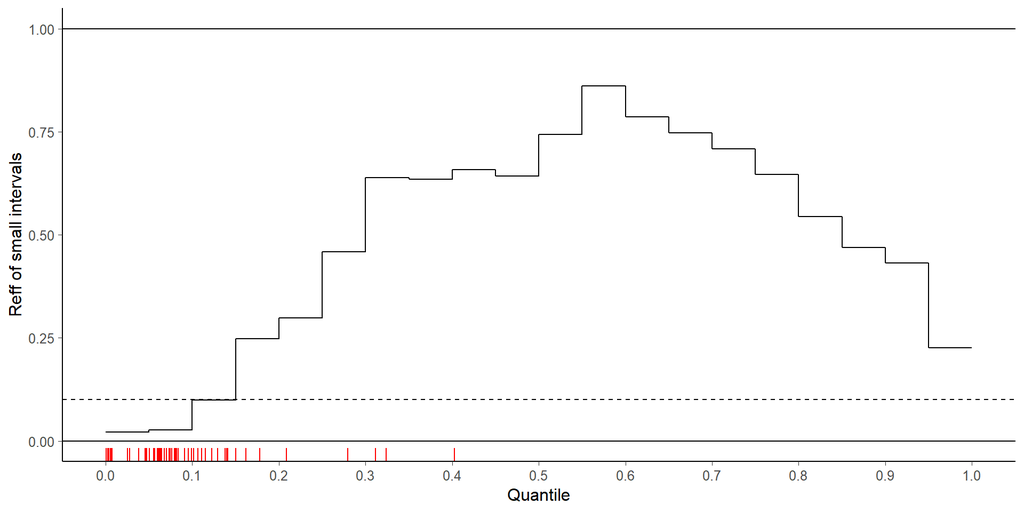

```r
plot_local_reff(fit = fit_cp, par = "tau", nalpha = 20)
```

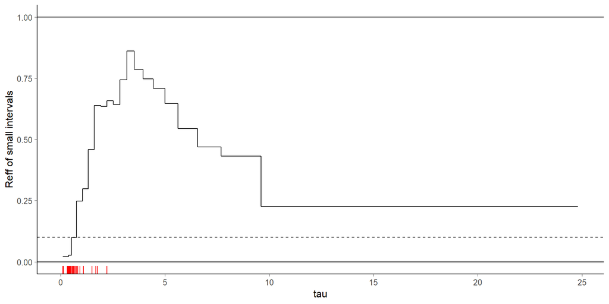

```r
plot_local_reff(fit = fit_cp, par = "tau", nalpha = 20, rank = FALSE)
```

We see that the sampler has difficulties in exploring small `tau` values. As the efficiency for estimating small `tau` values is practically zero, we may assume that we may miss substantial amount of posterior mass and get biased estimates. Red ticks, which show iterations with divergences, have concentrated to small `tau` values, indicate also problems exploring small values which is likely to cause bias.

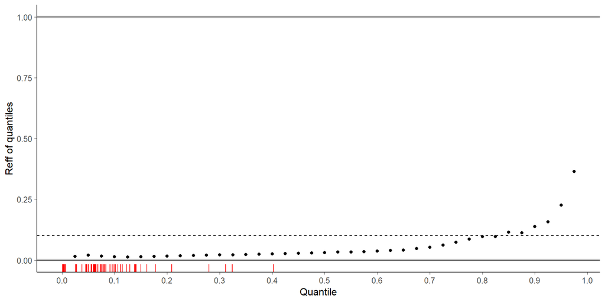

```r
plot_quantile_reff(fit = fit_cp, par = "tau", nalpha = 40)
```

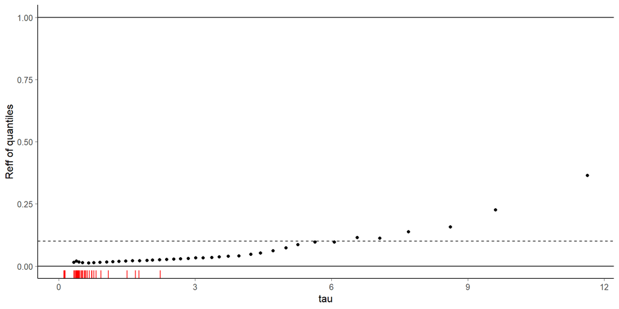

```r
plot_quantile_reff(fit = fit_cp, par = "tau", nalpha = 40, rank = FALSE)
```

Most of the quantile estimates have worryingly low relative efficiency.

Let’s see how the estimated relative efficiency changes when we use more and more draws.

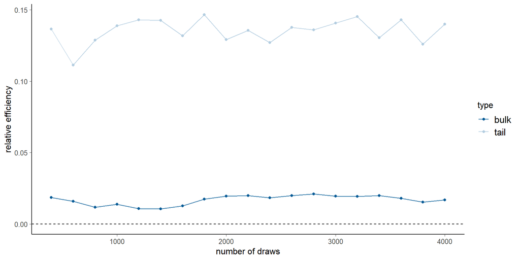

```r
plot_change_reff(fit = fit_cp, par = "tau")
```

In lines with these findings, the rank plots of `tau` clearly show problems in the mixing of the chains.

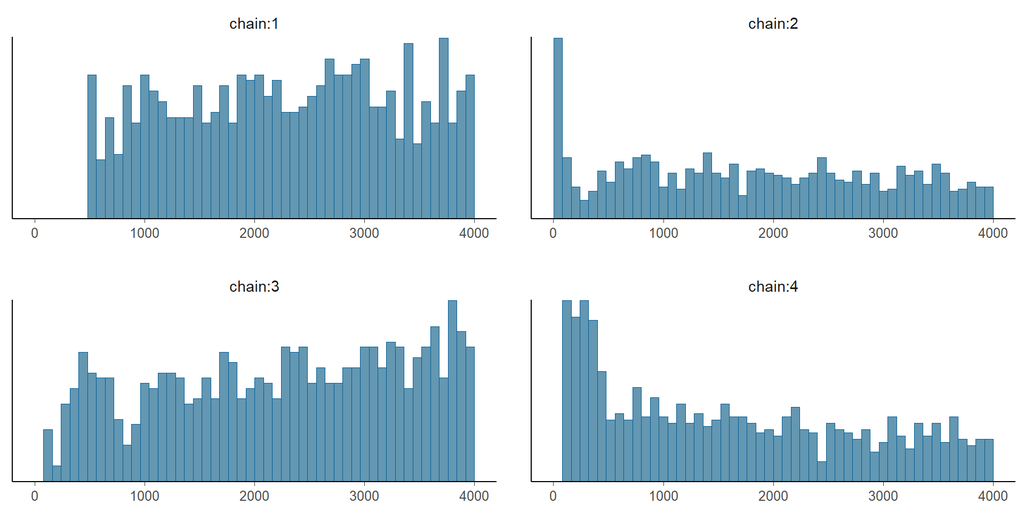

```r
samp_cp <- as.array(fit_cp)
mcmc_hist_r_scale(samp_cp[, , "tau"])
```

### 4.2.2 Non-centered Eight Schools model

For hierarchical models, the non-centered parameterization often works better than the centered one:

```r
writeLines(readLines("eight_schools_ncp.stan"))
```

```
data {
  int<lower=0> J;
  real y[J];
  real<lower=0> sigma[J];
}

parameters {
  real mu;
  real<lower=0> tau;
  real theta_tilde[J];
}

transformed parameters {
  real theta[J];
  for (j in 1:J)
    theta[j] = mu + tau * theta_tilde[j];
}

model {
  mu ~ normal(0, 5);
  tau ~ cauchy(0, 5);
  theta_tilde ~ normal(0, 1);
  y ~ normal(theta, sigma);
}
```

For reasons of comparability, we also run the non-centered parameterization model with an increased `adapt_delta` value:

```r
fit_ncp2 <- stan(
  file = 'eight_schools_ncp.stan', data = eight_schools,
  iter = 2000, chains = 4, seed = 483892929, refresh = 0,
  control = list(adapt_delta = 0.95)
)
```

We get zero divergences and no other warnings which is a first good sign.

```r
mon <- monitor(fit_ncp2)
print(mon)
```

```
Inference for the input samples (4 chains: each with iter = 2000; warmup = 1000):

                   Q5   Q50   Q95 SE_Q5 SE_Q50 SE_Q95 Rhat Bulk_Reff Tail_Reff
mu              -1.14  4.42  9.96  0.13   0.05   0.12    1      1.38      0.52
tau              0.30  2.81  9.50  0.03   0.05   0.14    1      0.72      0.84
theta_tilde[1]  -1.29  0.31  1.88  0.05   0.01   0.04    1      1.26      0.46
theta_tilde[2]  -1.44  0.11  1.62  0.04   0.02   0.04    1      1.04      0.50
theta_tilde[3]  -1.64 -0.08  1.48  0.03   0.02   0.03    1      1.62      0.52
theta_tilde[4]  -1.51  0.08  1.62  0.03   0.01   0.04    1      1.52      0.47
theta_tilde[5]  -1.71 -0.17  1.39  0.04   0.01   0.03    1      1.40      0.54
theta_tilde[6]  -1.64 -0.06  1.53  0.04   0.02   0.03    1      1.21      0.47
theta_tilde[7]  -1.25  0.40  1.87  0.04   0.01   0.03    1      1.20      0.53
theta_tilde[8]  -1.54  0.07  1.66  0.04   0.01   0.04    1      1.54      0.49
theta[1]        -1.62  5.64 16.31  0.17   0.11   0.50    1      1.23      0.64
theta[2]        -2.42  4.82 12.96  0.23   0.08   0.35    1      1.28      0.63
theta[3]        -4.63  4.26 12.10  0.23   0.05   0.17    1      1.36      0.70
theta[4]        -2.73  4.75 12.48  0.16   0.07   0.19    1      1.17      0.64
theta[5]        -3.96  3.82 11.02  0.19   0.06   0.15    1      1.34      0.68
theta[6]        -3.88  4.27 11.44  0.18   0.07   0.17    1      1.42      0.60
theta[7]        -0.98  5.88 15.43  0.11   0.09   0.25    1      1.18      0.66
theta[8]        -3.23  4.78 13.13  0.23   0.08   0.24    1      1.23      0.64
lp__           -11.19 -6.60 -3.78  0.12   0.05   0.06    1      0.41      0.65

For each parameter, Bulk_Reff and Tail_Reff are crude measures of relative
effective sample size for bulk and tail quantities respectively (good mixing
Reff > 0.1), and Rhat is the potential scale reduction factor on rank normalized
split chains (at convergence, Rhat = 1).
```

All Rhat < 1.01 and Rhat > 0.1 indicate a much better performance of the non-centered parameterization.

We examine the relative efficiency in different parts of the posterior by computing the relative efficiency of small interval probability estimates for `tau`.

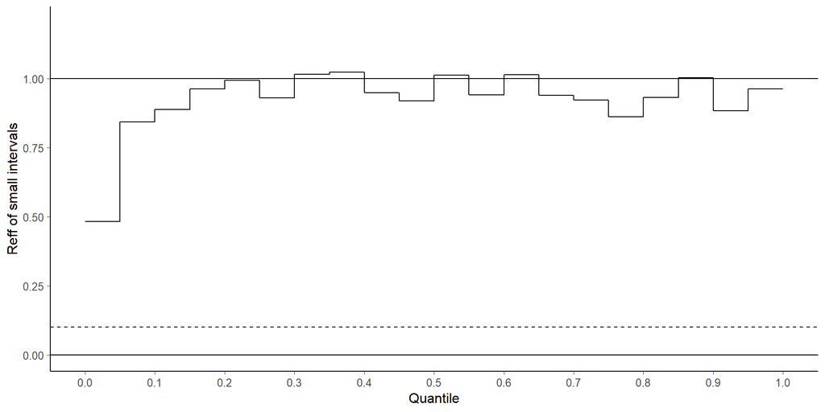

```r
plot_local_reff(fit = fit_ncp2, par = 2, nalpha = 20)
```

Small `tau` values are still more difficult to explore, but the relative efficiency is in a good range. We may also check this with a finer resolution:

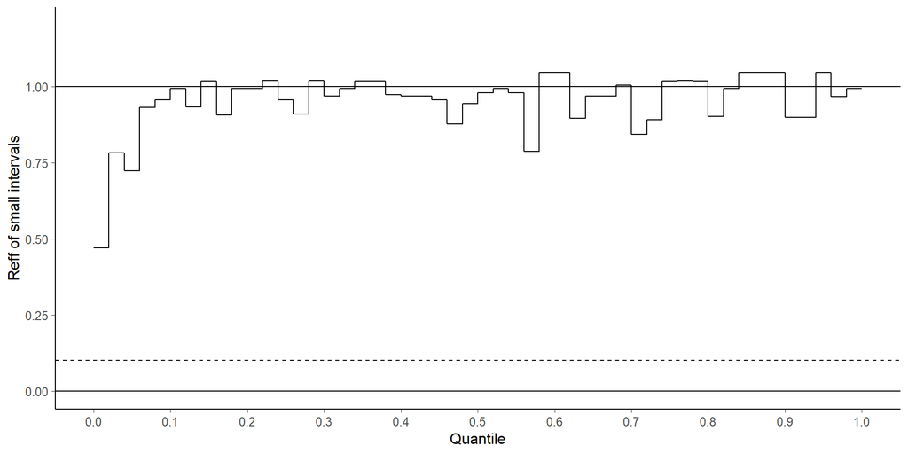

```r
plot_local_reff(fit = fit_ncp2, par = 2, nalpha = 50)
```

The relative efficiency of different quantile estimates looks good as well.

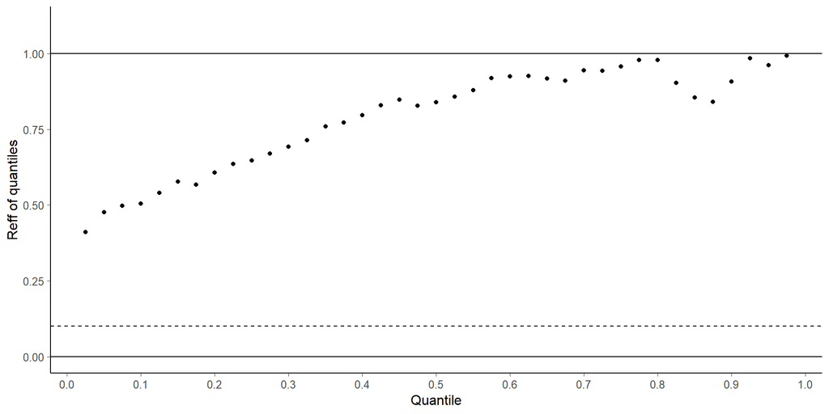

```r
plot_quantile_reff(fit = fit_ncp2, par = 2, nalpha = 40)
```

In line with these findings, the rank plots of `tau` show no substantial differences between chains.

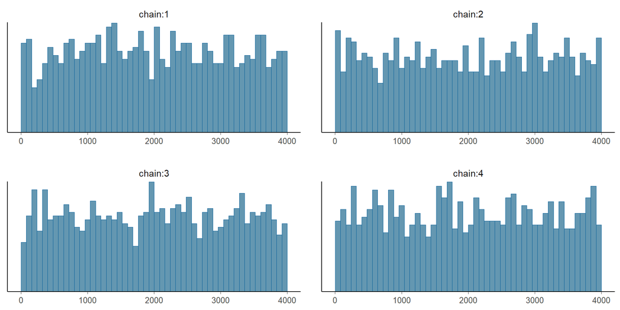

```r
samp_ncp2 <- as.array(fit_ncp2)
mcmc_hist_r_scale(samp_ncp2[, , 2])
```

# References

Betancourt, M. (2017) ‘A conceptual introduction to hamiltonian monte carlo’, *arXiv preprint arXiv:1701.02434*.

Brooks, S. P. and Gelman, A. (1998) ‘General methods for monitoring convergence of iterative simulations’, *Journal of Computational and Graphical Statistics*, 7(4), pp. 434–455.

Gelman, A. *et al.* (2013) *Bayesian data analysis, third edition*. CRC Press.

Gelman, A. and Rubin, D. B. (1992) ‘Inference from iterative simulation using multiple sequences’, *Statistical science*, 7(4), pp. 457–472.

Geyer, C. J. (1992) ‘Practical Markov chain Monte Carlo’, *Statistical Science*, 7, pp. 473–483.

Geyer, C. J. (2011) ‘Introduction to Markov chain Monte Carlo’, in Brooks, S. et al. (eds) *Handbook of markov chain monte carlo*. CRC Press.

Hoffman, M. D. and Gelman, A. (2014) ‘The No-U-Turn Sampler: Adaptively setting path lengths in Hamiltonian Monte Carlo’, *Journal of Machine Learning Research*, 15, pp. 1593–1623. Available at: http://jmlr.org/papers/v15/hoffman14a.html.

Stan Development Team (2018a) *Bayesian statistics using stan*. Stan Development Team. Available at: https://github.com/stan-dev/stan-book.

Stan Development Team (2018b) ‘RStanArm: Bayesian applied regression modeling via Stan. R package version 2.17.4’. Available at: http://mc-stan.org.

Stan Development Team (2018c) ‘RStan: The R interface to Stan. R package version 2.17.3’. Available at: http://mc-stan.org.

Stan Development Team (2018d) ‘Stan modeling language users guide and reference manual. Version 2.18.0’. Available at: http://mc-stan.org.

Stan Development Team (2018e) ‘The Stan core library version 2.18.0’. Available at: http://mc-stan.org.

# Appendices

## Appendix A: Abbreviations

The following abbreviations are used throughout the appendices:

- N = total number of draws
- Rhat = classic no-split-Rhat
- sRhat = classic split-Rhat
- zsRhat = rank-normalized split-Rhat
  - all chains are jointly ranked and z-transformed
  - can detect differences in location and trends
- zfsRhat = rank-normalized folded split-Rhat
  - all chains are jointly “folded” by computing absolute deviation from median, ranked and z-transformed
  - can detect differences in scales
- neff = no-split effective sample size
- reff = neff / N
- zsneff = rank-normalized split effective sample size
  - estimates the efficiency of mean estimate for rank normalized values
- zsreff = zsneff / N
- zfsneff = rank-normalized folded split effective sample size
  - estimates the efficiency of rank normalized *mean* absolute deviation
- zfsreff = zfsneff / N
- medsneff = median split effective sample size
  - estimates the efficiency of the median
- medsreff = medsneff / N
- madsneff = mad split effective sample size
  - estimates the efficiency of the median absolute deviation
- madsreff = madsneff / N

## Appendix B: Examples of rank normalization

We will illustrate the rank normalization with a few examples. First, we plot histograms, and empirical cumulative distribution functions (ECDF) with respect to the original parameter values ($\theta$), scaled ranks (ranks divided by the maximum rank), and rank normalized values (z). We used scaled ranks to make the plots look similar for different number of draws.

100 draws from Normal(0, 1):

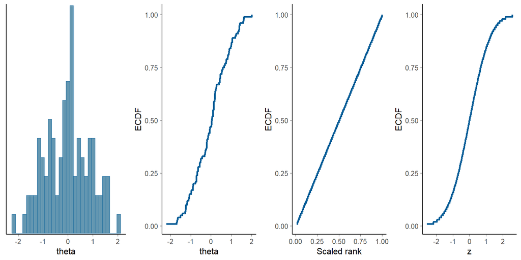

```r
n <- 100
theta <- rnorm(n)
plotranknorm(theta, n)
```

100 draws from Exponential(1):

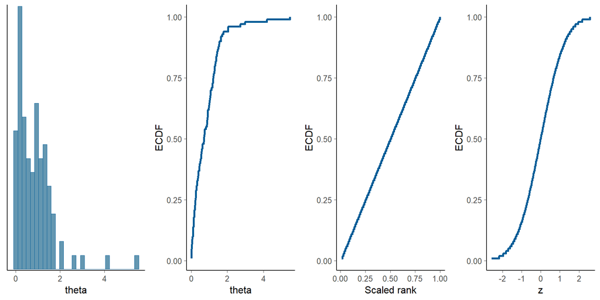

```r
theta <- rexp(n)
plotranknorm(theta, n)
```

100 draws from Cauchy(0, 1):

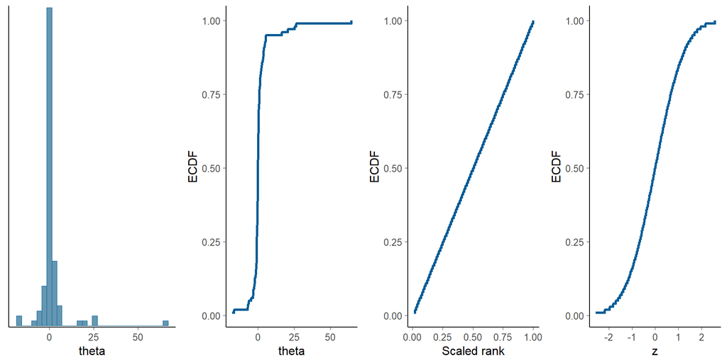

```r
theta <- rcauchy(n)
plotranknorm(theta, n)
```

In the above plots, the ECDF with respect to scaled rank and rank normalized $z$-values look exactly the same for all distributions. In *Split*-$\widehat{R}$ and effective sample size computations, we rank all draws jointly, but then compare ranks and ECDF of individual split chains. To illustrate the variation between chains, we draw 8 batches of 100 draws each from Normal(0, 1):

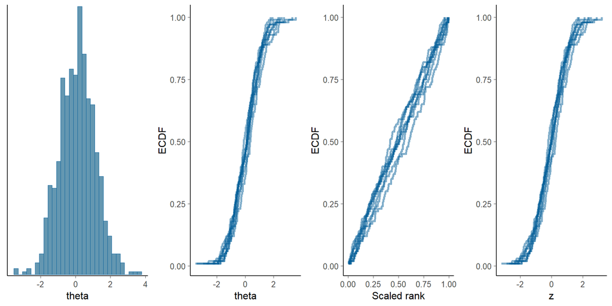

```r
n <- 100
m <- 8
theta <- rnorm(n * m)
plotranknorm(theta, n, m)
```

The variation in ECDF due to the variation ranks is now visible also in scaled ranks and rank normalized $z$-values from different batches.

The benefit of rank normalization is more obvious for non-normal distribution such as Cauchy:

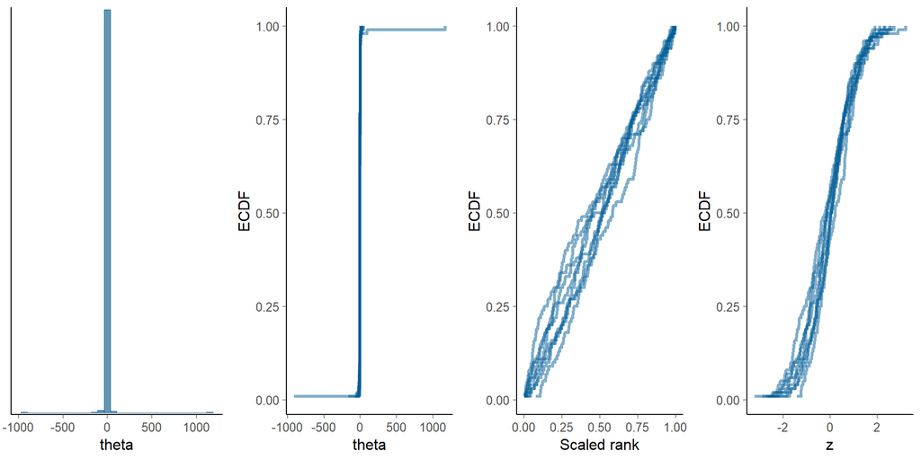

```r
theta <- rcauchy(n * m)
plotranknorm(theta, n, m)
```

Rank normalization makes the subsequent computations well defined and invariant under bijective transformations. This means that we get the same results, for example, if we use unconstrained or constrained parameterisations in a model.

## Appendix C: Variance of the cumulative distribution function

In Section 3, we had defined the empirical CDF (ECDF) for any $\theta_\alpha$ as
$$p(\theta \leq \theta_\alpha) \approx \bar{I}_\alpha = \frac{1}{S}\sum_{s=1}^S
I(\theta^{(s)} \leq\theta_\alpha),$$

For independent draws, $\bar{I}_\alpha$ has a ${\rm Beta}(\bar{I}_\alpha+1, S - \bar{I}_\alpha + 1)$ distribution. Thus we can easily examine the variation of the ECDF for any $\theta_\alpha$ value from a single chain. If $\bar{I}_\alpha$ is not very close to $1$ or $S$ and $S$ is large, we can use the variance of Beta distribution

$${\rm Var}[p(\theta \leq \theta_\alpha)] =
\frac{(\bar{I}_\alpha+1)*(S-\bar{I}_\alpha+1)}{(S+2)^2(S+3)}.$$
We illustrate uncertainty intervals of the Beta distribution and normal approximation of ECDF for 100 draws from Normal(0, 1):

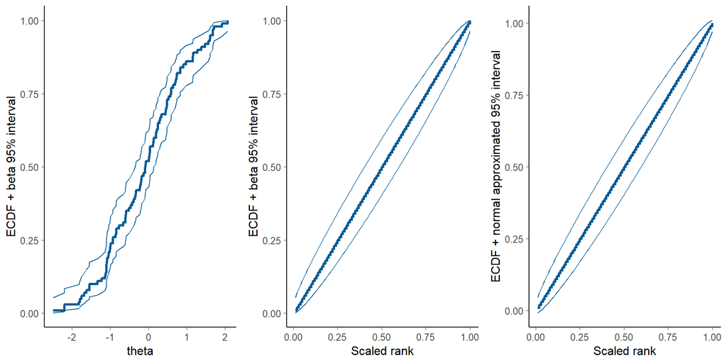

```r
n <- 100
m <- 1
theta <- rnorm(n*m)
plotranknorm(theta, n, m, interval = TRUE)
```

Uncertainty intervals of ECDF for draws from Cauchy(0, 1) illustrate again the improved visual clarity in plotting when using scaled ranks:

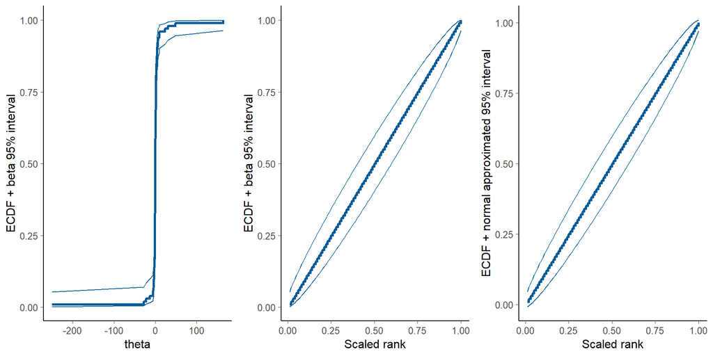

```r
n <- 100
m <- 1
theta <- rcauchy(n*m)
plotranknorm(theta, n, m, interval = TRUE)
```

The above plots illustrate that the normal approximation is accurate for practical purposes in MCMC diagnostics.

## Appendix D: Normal distributions with additional trend, shift or scaling

This part focuses on diagnostics for

- all chains having a trend and a similar marginal distribution
- one of the chains having a different mean
- one of the chains having a lower marginal variance

To simplify, in this part, independent draws are used as a proxy for very efficient MCMC sampling. First, we sample draws from a standard-normal distribution. We will discuss the behavior for non-normal distributions later. See Appendix A for the abbreviations used.

### 4.2.3 Adding the same trend to all chains

All chains are from the same Normal(0, 1) distribution plus a linear trend added to all chains:

```r
conds <- expand.grid(
  iters = c(250, 1000, 4000),
  trend = c(0, 0.25, 0.5, 0.75, 1),
  rep = 1:10
)
res <- vector("list", nrow(conds))
chains = 4
for (i in 1:nrow(conds)) {
  iters <- conds[i, "iters"]
  trend <- conds[i, "trend"]
  rep <- conds[i, "rep"]
  r <- array(rnorm(iters * chains), c(iters, chains))
  r <- r + seq(-trend, trend, length.out = iters)
  rs <- as.data.frame(monitor_extra(r))
  res[[i]] <- cbind(iters, trend, rep, rs)
}
res <- bind_rows(res)
```

If we don’t split chains, Rhat misses the trends if all chains still have a similar marginal distribution.

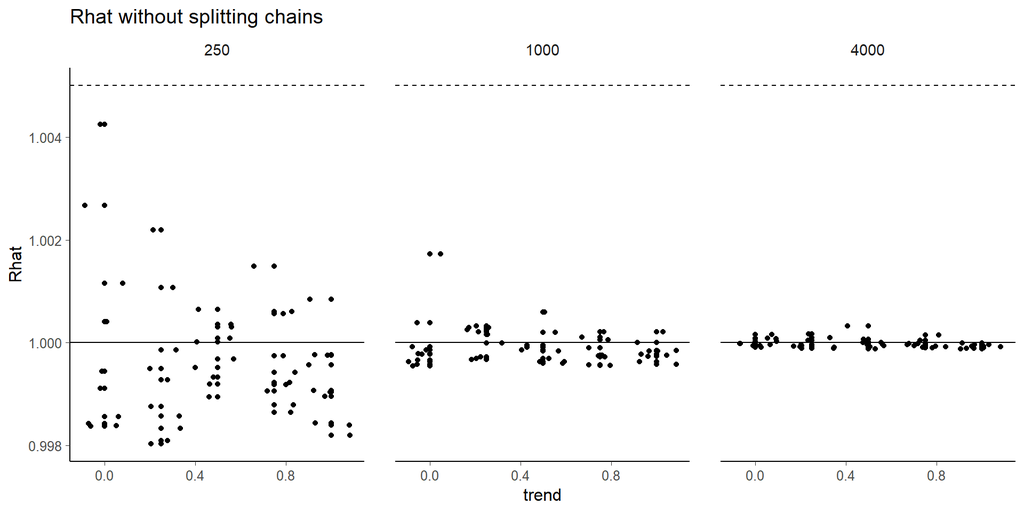

```r
ggplot(data = res, aes(y = Rhat, x = trend)) +
  geom_point() +
  geom_jitter() +
  facet_grid(. ~ iters) +
  geom_hline(yintercept = 1.005, linetype = 'dashed') +
  geom_hline(yintercept = 1) +
  ggtitle('Rhat without splitting chains')
```

Split-Rhat can detect trends, even if the marginals of the chains are similar.

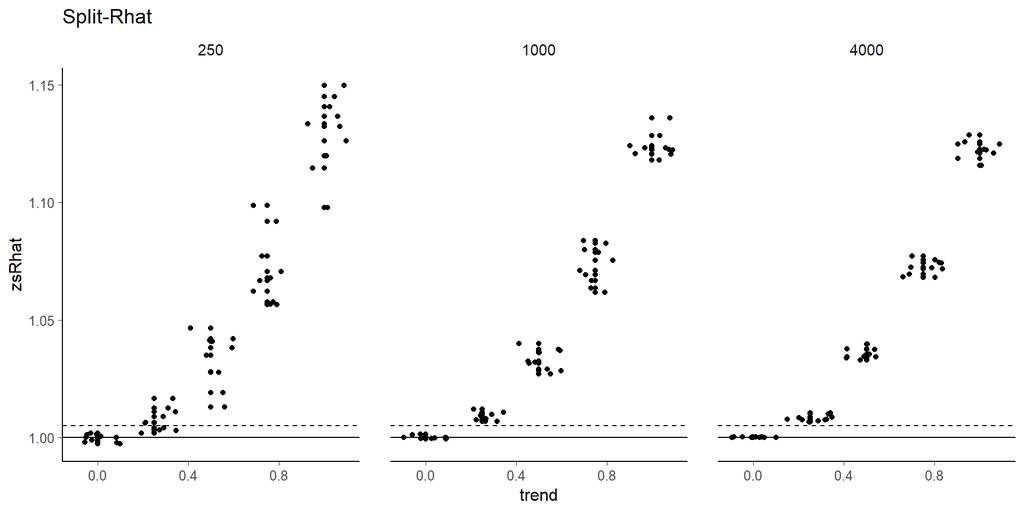

```r
ggplot(data = res, aes(y = zsRhat, x = trend)) +
  geom_point() + geom_jitter() +
  facet_grid(. ~ iters) +
  geom_hline(yintercept = 1.005, linetype = 'dashed') +
  geom_hline(yintercept = 1) +
  ggtitle('Split-Rhat')
```

**Result:** Split-Rhat is useful for detecting non-stationarity (i.e., trends) in the chains. If we use a threshold of $1.01$, we can detect trends which account for 2% or more of the total marginal variance. If we use a threshold of $1.1$, we can detect trends which account for 30% or more of the total marginal variance.

Relative efficiency (effective sample size divided by the number of draws) is based on split Rhat and within-chain autocorrelation.

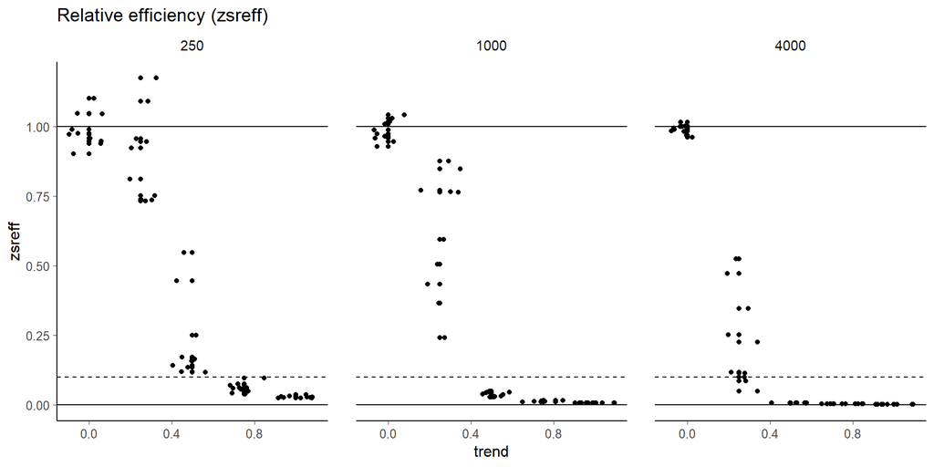

```r
ggplot(data = res, aes(y = zsreff, x = trend)) +
  geom_point() +
  geom_jitter() +
  facet_grid(. ~ iters) +
  geom_hline(yintercept = c(0,1)) +
  geom_hline(yintercept = 0.1, linetype = 'dashed') +
  ggtitle('Relative efficiency (zsreff)') +
  scale_y_continuous(breaks = seq(0, 1, by = 0.25))
```

**Result:** Split-Rhat is more sensitive to trends for small sample sizes, but relative efficiency becomes more sensitive for larger samples sizes (as autocorrelations can be estimated more accurately).

**Advice:** If in doubt, run longer chains for more accurate convergence diagnostics.

### 4.2.4 Shifting one chain

Next we investigate the sensitivity to detect if one of the chains has not converged to the same distribution as the others, but has a different mean.

```r
conds <- expand.grid(
  iters = c(250, 1000, 4000),
  shift = c(0, 0.25, 0.5, 0.75, 1),
  rep = 1:10
)
res <- vector("list", nrow(conds))
chains = 4
for (i in 1:nrow(conds)) {
  iters <- conds[i, "iters"]
  shift <- conds[i, "shift"]
  rep <- conds[i, "rep"]
  r <- array(rnorm(iters * chains), c(iters, chains))
  r[, 1] <- r[, 1] + shift
  rs <- as.data.frame(monitor_extra(r))
  res[[i]] <- cbind(iters, shift, rep, rs)
}
res <- bind_rows(res)
```

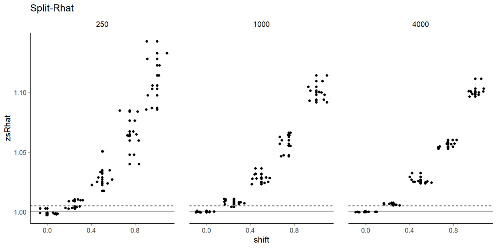

```r
ggplot(data = res, aes(y = zsRhat, x = shift)) +
  geom_point() +
  geom_jitter() +
  facet_grid(. ~ iters) +
  geom_hline(yintercept = 1.005, linetype = 'dashed') +
  geom_hline(yintercept = 1) +
  ggtitle('Split-Rhat')
```

**Result:** If we use a threshold of $1.01$, we can detect shifts with a magnitude of one third or more of the marginal standard deviation. If we use a threshold of $1.1$, we can detect a shift with a magnitude equal to or larger than the marginal standard deviation.

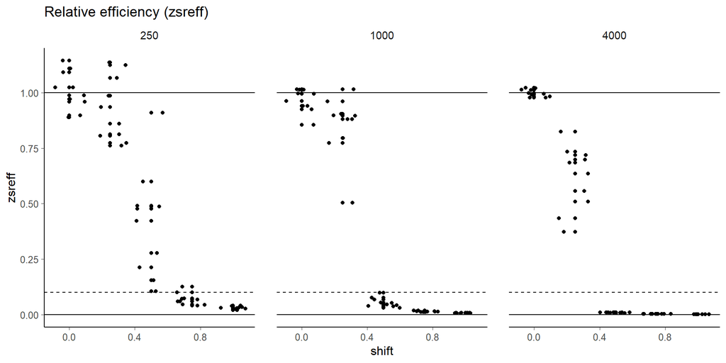

```r
ggplot(data = res, aes(y = zsreff, x = shift)) +
  geom_point() +
  geom_jitter() +
  facet_grid(. ~ iters) +
  geom_hline(yintercept = c(0,1)) +
  geom_hline(yintercept = 0.1, linetype = 'dashed') +
  ggtitle('Relative efficiency (zsreff)') +
  scale_y_continuous(breaks = seq(0, 1, by = 0.25))
```

**Result:** The relative efficiency is not as sensitive, but a shift with a magnitude of half the marginal standard deviation or more will lead to very low efficiency when sample size increases.

Rank plots can be used to visualize differences between chains. Here, we show rank plots for the case of 4 chains, 250 draws per chain, and a shift of 0.5.

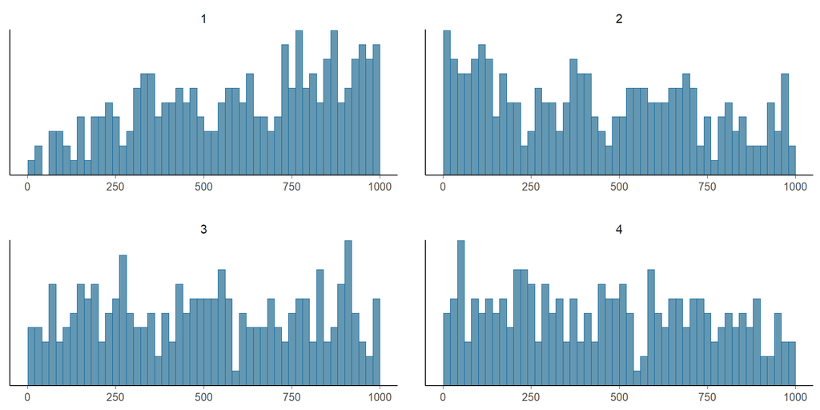

```r
iters = 250
chains = 4
shift = 0.5
r <- array(rnorm(iters * chains), c(iters, chains))
r[, 1] <- r[, 1] + shift
colnames(r) <- 1:4
mcmc_hist_r_scale(r)
```

Although, Rhat was less than $1.05$ for this situation, the rank plots clearly show that the first chains behaves differently.